# Property Value Prediction Using Clustering and Linear Regression - Automated Valuation Model (AVM)

Tyler Blakeley, Benjamin Kan, Mohammad Islam, Avijeet Singh

November 16 2018

# 1 Business Understanding

We are the owners of a start-up company based in New York City who specializes in appraisal management and national real estate information, servicing major banks, lenders, mortgage insurers, credit unions, and independent mortgage brokers. Currently, most of the real estate transactions including mortgage loans and commercial property acquisitions rely on appraisers to estimate the property values. However, this could take at least days to complete, which the mortgage lenders and brokers think takes too long given the hyper competitive nature of the real estate industry. Moreover, the property valuation process is at times manual without comprehensive substantiation of how the appraisers come up with the values. Therefore, we reckon that the real estate appraisal industry is ripe for disruption. Our product is a property value prediction model which can be used by mortgage lenders and brokers to value the properties within minutes. It is a national solution built using highly advanced machine learning algorithms, which can take into account extensive and diverse data sets, learn from the data in their environment, as well as incorporate new and different situations, as the market evolves.

# 2 Data Understanding

## 2.1 Data Source and Collection

We sourced the NYC property sales data from Kaggle (https://www.kaggle.com/new-york-city/nyc-property-sales/home). This dataset contains the properties sold in NYC over a 12-month period from September 2016 to September 2017. The dataset contains 22 attributes including the precise property locations (Borough, Neighborhood, Block, Zip Code and Address), building class, property types (Residential or Commercial), property size and tax class. The dataset consists of about 84.5K of property sale transactions.

## 2.2 Data Description

In the dataset, there are 22 variables. A detailed description of these variables can be found at https://www1.nyc.gov/assets/finance/downloads/pdf/07pdf/glossary_rsf071607.pdf

| Variable Name | Description |
| --- | --- |
| # | ID of the property |
| BOROUGH | The name of the borough in which the property is located |
| NEIGHBORHOOD | Neighborhood name in the course of valuing properties |
| BUILDING CLASS CATEGORY | Building class descriptions |
| TAX CLASS | 1: Residential property up to three units; 2: All other property that is |
| BLOCK | Sub-division of the borough on which the real properties are located |
| LOT | Subdivision of a block and represents the property unique location |
| EASEMENT | A right which allows an entity to make limited use of another’s real |
| BUILDING CLASS AT PRESENT | Building Code. Details can be found at |
| https://www1.nyc.gov/assets/finance/jump/hlpbldgcode.html |  |
| ADDRESS | Street address of the property as listed on the Sales File. Coop sales |
| ZIP CODE | The property’s postal code |
| RESIDENTIAL UNITS | The number of residential units at the listed property |
| COMMERCIAL UNITS | The number of commercial units at the listed property |
| LAND SQUARE FEET | The land area of the property listed in square feet |
| GROSS SQUARE FEET | The total area of all the floors of a building as measured from the exterior |
| YEAR BUILT | Year the structure on the property was built |
| BUILDING CLASS AT TIME OF SALE | The Building Classification is used to describe a property’s constructive |
| SALES PRICE | Price paid for the property |
| SALE DATE | Date of property sold |

Note: $0 Sales Price: A $0 sale indicates that there was a transfer of ownership without a cash consideration. There can be a number of reasons for a $0 sale including transfers of ownership from parents to children.

## 2.3 Data Quality Checks and Prelimiary Data Cleaning

### 2.3.1 Load Packages

```r
#import packages;
library(dplyr)
library(reshape2)
library(ggplot2)
library(Hmisc)
library(corrplot)
library(mice)
library(VIM)
library(pROC)
library(caret)
library(corrgram)
library(GGally)
library(ggthemes)
library(DMwR)
library(gridExtra)
library(rattle)
library(readxl)
library(cluster)
library(sqldf)
library(knitr)
library(xgboost)
library(outliers)
```

### 2.3.2 Load Datasets

Now that the packages are loaded, we can load in the dataset.

```r
data <- read.csv(file.choose(), header = TRUE, na.strings = c("NA","","#NA"," -  "))
```

Now let us see how our dataset looks like:

```r
str(data)
```

```
## 'data.frame':    84548 obs. of  22 variables:
##  $ X                             : int  4 5 6 7 8 9 10 11 12 13 ...
##  $ BOROUGH                       : int  1 1 1 1 1 1 1 1 1 1 ...
##  $ NEIGHBORHOOD                  : Factor w/ 254 levels "AIRPORT LA GUARDIA",..: 2 2 2 2 2 2 2 2 2 2 ...
##  $ BUILDING.CLASS.CATEGORY       : Factor w/ 47 levels "01 ONE FAMILY DWELLINGS                    ",..: 7 7 7 7 7 7 7 7 8 8 ...
##  $ TAX.CLASS.AT.PRESENT          : Factor w/ 11 levels " ","1","1A","1B",..: 7 6 6 8 7 6 8 6 6 6 ...
##  $ BLOCK                         : int  392 399 399 402 404 405 406 407 379 387 ...
##  $ LOT                           : int  6 26 39 21 55 16 32 18 34 153 ...
##  $ EASE.MENT                     : logi  NA NA NA NA NA NA ...
##  $ BUILDING.CLASS.AT.PRESENT     : Factor w/ 167 levels " ","A0","A1",..: 17 22 22 19 17 19 19 22 31 35 ...
##  $ ADDRESS                       : Factor w/ 67563 levels "****** 95TH   STREET",..: 14951 28602 22213 15133 35432 49353 24812 49575 11712 53854 ...
##  $ APARTMENT.NUMBER              : Factor w/ 3989 levels " ","#4","#PHC",..: 1 1 1 1 1 1 1 1 1 1 ...
##  $ ZIP.CODE                      : int  10009 10009 10009 10009 10009 10009 10009 10009 10009 10009 ...
##  $ RESIDENTIAL.UNITS             : int  5 28 16 10 6 20 8 44 15 24 ...
##  $ COMMERCIAL.UNITS              : int  0 3 1 0 0 0 0 2 0 0 ...
##  $ TOTAL.UNITS                   : int  5 31 17 10 6 20 8 46 15 24 ...
##  $ LAND.SQUARE.FEET              : int  1633 4616 2212 2272 2369 2581 1750 5163 1534 4489 ...
##  $ GROSS.SQUARE.FEET             : int  6440 18690 7803 6794 4615 9730 4226 21007 9198 18523 ...
##  $ YEAR.BUILT                    : int  1900 1900 1900 1913 1900 1900 1920 1900 1920 1920 ...
##  $ TAX.CLASS.AT.TIME.OF.SALE     : int  2 2 2 2 2 2 2 2 2 2 ...
##  $ BUILDING.CLASS.AT.TIME.OF.SALE: Factor w/ 166 levels "A0","A1","A2",..: 16 21 21 18 16 18 18 21 30 34 ...
##  $ SALE.PRICE                    : num  6625000 NA NA 3936272 8000000 ...
##  $ SALE.DATE                     : Factor w/ 364 levels "2016-09-01 00:00:00",..: 321 105 100 23 78 322 23 322 292 68 ...
```

From the above we can see that first column has only the observation numbers and is not necessary for our data exploration and modeling proesses so we will remove it.

```r
data <- as_data_frame(data[,-1])
```

### 2.3.3 Residential Data Selection

Based on our business case, we only want to create a model to predit the prices of the residentential homes. We will then remove any sales data that are not residenttial homes based on the BUILDING.CLASS.CATEGORY.

```r
#Remove any home with facilities in its class
data <- data[!data$BUILDING.CLASS.CATEGORY %like% 'FACILITIES',]

#Remove any commerical
data <- data[!data$BUILDING.CLASS.CATEGORY %like% 'COMMERCIAL',]

#Remove office
data <- data[!data$BUILDING.CLASS.CATEGORY %like% 'OFFICE',]

#Remove HOTEL
data <- data[!data$BUILDING.CLASS.CATEGORY %like% 'HOTEL',]

#Remove Vacant Land
data <- data[!data$BUILDING.CLASS.CATEGORY %like% 'VACANT LAND',]

#Remove Other
data <- data[!data$BUILDING.CLASS.CATEGORY %like% 'OTHER',]

#Remove PARK
data <- data[!data$BUILDING.CLASS.CATEGORY %like% 'PARK',]

#Remove WAREHOUSE
data <- data[!data$BUILDING.CLASS.CATEGORY %like% 'WAREHOUSE',]

#Remove STORE
data <- data[!data$BUILDING.CLASS.CATEGORY %like% 'STORE',]

#Remove FACTORY
data <- data[!data$BUILDING.CLASS.CATEGORY %like% 'FACTOR',]

#Remove ASYLUM
data <- data[!data$BUILDING.CLASS.CATEGORY %like% 'ASYLUM',]

#Remove RENTAL
data <- data[!data$BUILDING.CLASS.CATEGORY %like% 'RENTAL',]
```

### 2.3.4 Remove Number Codes in the Building Class Category

As we examine the BUILDING.CLASS.CATEGORY more, we notice that the some categories start with number codes.We think that this information is redundant and could introduce unnecessary complexity. Therefore, we will set up a new column which will only give us the BUILDING CLASS CATEGORY without the number codes i.e “walkup aprartments”,“elevator apartments” etc.

```r
data$BUILDING.CLASS.CATEGORY<-substring(data$BUILDING.CLASS.CATEGORY,3)
head(data$BUILDING.CLASS.CATEGORY)
```

```
## [1] " COOPS - WALKUP APARTMENTS               "
## [2] " COOPS - WALKUP APARTMENTS               "
## [3] " COOPS - WALKUP APARTMENTS               "
## [4] " COOPS - WALKUP APARTMENTS               "
## [5] " COOPS - WALKUP APARTMENTS               "
## [6] " COOPS - WALKUP APARTMENTS               "
```

### 2.3.5 Consolidate Condos and Coops Building Class Categories

We would like reduce the number of factors under the condos and coops building types by grouping various types of condos and coops as “CONDOS” and “COOP” respectively.

```r
#Combine CONDO and COOP
data$BUILDING.CLASS.CATEGORY <- as.character(data$BUILDING.CLASS.CATEGORY)
data$BUILDING.CLASS.CATEGORY <- ifelse(data$BUILDING.CLASS.CATEGORY %like% 'CONDO', "CONDO",data$BUILDING.CLASS.CATEGORY)
data$BUILDING.CLASS.CATEGORY <- ifelse(data$BUILDING.CLASS.CATEGORY %like% 'COOP', "COOP",data$BUILDING.CLASS.CATEGORY)
data$BUILDING.CLASS.CATEGORY <- as.factor(data$BUILDING.CLASS.CATEGORY)
```

### 2.3.6 Borough

Currently, the Borough column is numeric to represent the five boroughs in New York City: Manhattan (1), Bronx (2), Brooklyn (3), Queens (4), and Staten Island (5). We will name the boroughs with proper names to provide more clarity and make our lives easier for the modeling work.

```r
data$BOROUGH <- ifelse(data$BOROUGH==1,'Manhattan',data$BOROUGH)
data$BOROUGH <- ifelse(data$BOROUGH==2,'Bronx',data$BOROUGH)
data$BOROUGH <- ifelse(data$BOROUGH==3,'Brooklyn',data$BOROUGH)
data$BOROUGH <- ifelse(data$BOROUGH==4,'Queens',data$BOROUGH)
data$BOROUGH <- ifelse(data$BOROUGH==5,'Staten Island',data$BOROUGH)
```

### 2.3.7 EASE-MENT

We will remove the column “EASE-MENT” as it has null value throughout:

```r
data$EASE.MENT<-NULL
```

### 2.3.8 Add the Building Age Column

Now let us introduce a new column “Building Age” in years as it is much easier to understand.

```r
data$BUILDING.AGE<- 2018 - data$YEAR.BUILT
```

### 2.3.9 Check for Duplicate Data and Remove Those

Let us finally check for duplicates and remove if there are any:

```r
data %>% filter(duplicated(data) == TRUE) %>% nrow()
```

```
## [1] 464
```

From here we can see that there are 464 duplicated data elements in which we will remove them.

Removing duplicates:

```r
data <- unique(data)
```

### 2.3.10 Data Type conversions

The original dataset has columns with types that are not suitable for analysis so we will convert them to suitable types.

- The Boroughs, Building Class Category, Zipcode, Tax class are converted to factors.
- Address, Apartment Number converted to characters.
- Land Square Feet, Gross Square Feet, Year are converted to numeric.
- Sale Date is converted to the date format.

```r
fac<-c(1,3,10,17)
data[fac]<-lapply(data[fac],factor)
chr<-c(8,9)
data[chr]<-lapply(data[chr],as.character)
num<-c(14,15)
data[num]<-lapply(data[num],as.numeric)
dt<-c(20)
data[dt]<-lapply(data[dt],as.Date)
```

Let’s now look at the data structure once again

```r
str(data)
```

```
## Classes 'tbl_df', 'tbl' and 'data.frame':    72206 obs. of  21 variables:
##  $ BOROUGH                       : Factor w/ 5 levels "Bronx","Brooklyn",..: 3 3 3 3 3 3 3 3 3 3 ...
##  $ NEIGHBORHOOD                  : Factor w/ 254 levels "AIRPORT LA GUARDIA",..: 2 2 2 2 2 2 2 2 2 2 ...
##  $ BUILDING.CLASS.CATEGORY       : Factor w/ 8 levels " LOFT BUILDINGS                          ",..: 8 8 8 8 8 8 8 8 8 8 ...
##  $ TAX.CLASS.AT.PRESENT          : Factor w/ 11 levels " ","1","1A","1B",..: 6 6 6 6 6 6 6 6 9 6 ...
##  $ BLOCK                         : int  373 373 373 373 373 373 373 373 374 375 ...
##  $ LOT                           : int  40 40 40 40 40 46 49 49 8 30 ...
##  $ BUILDING.CLASS.AT.PRESENT     : Factor w/ 167 levels " ","A0","A1",..: 21 21 21 21 21 21 21 21 21 21 ...
##  $ ADDRESS                       : chr  "327 EAST 3 STREET, 1C" "327 EAST 3 STREET, 1C" "327 EAST 3 STREET, 3A" "327 EAST 3RD STREET, 5A" ...
##  $ APARTMENT.NUMBER              : chr  " " " " " " " " ...
##  $ ZIP.CODE                      : Factor w/ 184 levels "0","10001","10002",..: 9 9 9 9 9 9 9 9 9 9 ...
##  $ RESIDENTIAL.UNITS             : int  0 0 0 0 0 0 0 0 0 0 ...
##  $ COMMERCIAL.UNITS              : int  0 0 0 0 0 0 0 0 0 0 ...
##  $ TOTAL.UNITS                   : int  0 0 0 0 0 0 0 0 0 0 ...
##  $ LAND.SQUARE.FEET              : num  NA NA NA NA NA NA NA NA NA NA ...
##  $ GROSS.SQUARE.FEET             : num  NA NA NA NA NA NA NA NA NA NA ...
##  $ YEAR.BUILT                    : int  1920 1920 1920 1920 1920 1925 1920 1920 1900 1902 ...
##  $ TAX.CLASS.AT.TIME.OF.SALE     : Factor w/ 4 levels "1","2","3","4": 2 2 2 2 2 2 2 2 2 2 ...
##  $ BUILDING.CLASS.AT.TIME.OF.SALE: Factor w/ 166 levels "A0","A1","A2",..: 20 20 20 20 20 20 20 20 20 20 ...
##  $ SALE.PRICE                    : num  1 499000 10 529500 423000 ...
##  $ SALE.DATE                     : Date, format: "2016-09-06" "2017-03-10" ...
##  $ BUILDING.AGE                  : num  98 98 98 98 98 93 98 98 118 116 ...
```

We are now at the stage where we can perform some data exploration. We will further fine tune our dataset as we go along.

## 2.4 Data Exploration and Outlier Analysis

### 2.4.1 Sale Price

First let us see the summary of sale price and then if the data is skewed by using the quantile function and box plot.

```r
summary(data$SALE.PRICE)
```

```
##     Min.  1st Qu.   Median     Mean  3rd Qu.     Max.     NA's
##        0   270000   540000   901363   908641 98525704    11098
```

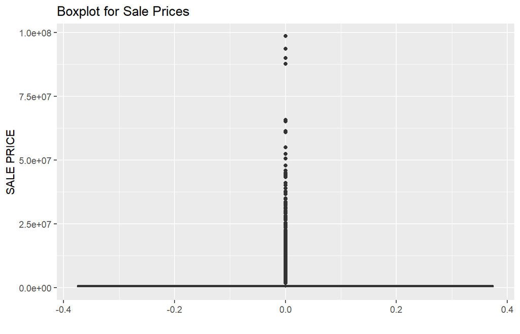

```r
#quantile(data$SALE.PRICE, probs = seq(from = 0, to = 1, by = .1))

ggplot(data, aes(,data$SALE.PRICE)) + geom_boxplot(fill = "white")+  scale_y_continuous("SALE PRICE")+scale_x_continuous("")+labs(title="Boxplot for Sale Prices")
```

As we can see, there are zero sale prices and substantial number of properties with very low sale prices which might not be correct. We will remove the outliers using the algorithms used in box and whisker plots.

```r
#Remove sale prices with 0s and NAs, and with very low and high values (outliers)

data <- data[data$SALE.PRICE != 0,]
data <- data[!is.na(data$SALE.PRICE),]

data_rm_outliers <- data;

remove_outliers <- function(x,lbound) {
  qnt <- quantile(x, probs=c(.25, .75), na.rm = TRUE)
  H <- 1.5 * IQR(x, na.rm = TRUE)
  y=x
  y[x < (qnt[1] - H/lbound)] = -999999
  y[x > (qnt[2] + H)] = -999999
  y

}

data$SALE.PRICE <- remove_outliers(data_rm_outliers$SALE.PRICE,4)

data <- data[data$SALE.PRICE!=-999999,]
```

We have removed the missing and outlier SALE.PRICE data. When we were removing outliers, we noticed that it was not removing any small values of SALE.PRICE, this was due to the fact that the minimum whisker was going negative and there is no sale price that is below zero. We made a small change where we divide the inter quartile range by 4 for the minimum whisker to remove some small values of sale prices.

We have reduced our dataset to 46153 oberservations.

### 2.4.2 Data Quality and Outlier Analysis for Gross.SQUARE.FEET, LAND.SQUARE.FEET and YEAR.BUILT

#### 2.4.2.1 LAND.SQUARE.FEET

We noticed there are zero values for LAND.SQUARE.FEET, we want to investigate if this is an error or if there are some types of properties that have zero lot sizes. Specifically, we want to look at what is the LAND.SQUARE.FEET for condos.

First we will see how the data looks like:

```r
summary(data$LAND.SQUARE.FEET)
```

```
##    Min. 1st Qu.  Median    Mean 3rd Qu.    Max.    NA's
##       0    1360    2187    2556    3142 4228300   16181
```

Let us check for outliers

```r
outlier(data$LAND.SQUARE.FEET)
```

```
## [1] 4228300
```

Let us try to find out how the sale price is per land sq. feet.

First we will check for NA’s in the Land square feet attribute:

```r
sum(is.na(data$LAND.SQUARE.FEET))
```

```
## [1] 16181
```

We can see that there are 16181 instances with NAs and we will remove these for the time being to find the relationship between the square footage and the sale price. For this purpose only we will create a new data frame “nyc_data_sqfeet” and we will plot the graphs using this dataframe.

```r
nyc_data_sqfeet <- as_data_frame(data[!is.na(data$LAND.SQUARE.FEET),])
```

Now that we have created the new data frame let us check for the relation between the square footage and the sale price.

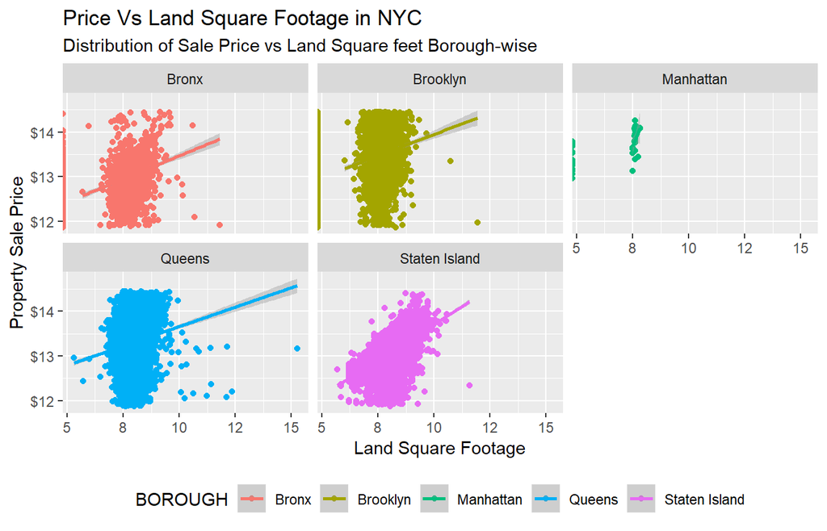

```r
ggplot(data = nyc_data_sqfeet, aes(x = log(nyc_data_sqfeet$LAND.SQUARE.FEET), y = log(nyc_data_sqfeet$SALE.PRICE), color = `BOROUGH`)) +
  geom_jitter() +
  geom_smooth(method = "lm") +
  theme(legend.position = "bottom") +
   ggtitle("Price Vs Land Square Footage in NYC",
          subtitle = "Distribution of Sale Price vs Land Square feet Borough-wise") +
  scale_y_continuous("Property Sale Price", labels = scales::dollar) +
  scale_x_continuous("Land Square Footage", labels = scales::comma) +
   facet_wrap(~ BOROUGH)
```

We can see that the sale price increases with the square footage across all boroughs except Manhattan. It could be because the distribution of the square footage of properties in Manhattan is not as dispersed so the log of the values is even more concentrated.

```r
#Investigate Land square feet with zero values

sqldf('SELECT [BUILDING.CLASS.CATEGORY],COUNT(*) FROM data where [LAND.SQUARE.FEET] = 0 group by [BUILDING.CLASS.CATEGORY]')
```

```
##   BUILDING.CLASS.CATEGORY COUNT(*)
## 1                   CONDO     3747
## 2                    COOP     2856
```

We can see that the only type of houses with 0 LAND.SQUARE.FEET are condos and coops and this does not seem to be an error and requires no imputation.

#### 2.4.2.2 GROSS.SQUARE.FEET

For GROSS.SQUARE.FEET we replaced any 0 values with NA, our assumaption is that no house can have 0 living area.

First we will see how the data looks like:

```r
summary(data$GROSS.SQUARE.FEET)
```

```
##    Min. 1st Qu.  Median    Mean 3rd Qu.    Max.    NA's
##       0     910    1462    1708    2080 3750565   16297
```

Let us check for outliers

```r
outlier(data$GROSS.SQUARE.FEET)
```

```
## [1] 3750565
```

Let us try to find out how the sale price is per gros sq. feet. First we will check for NA’s in the gross square feet attribute:

```r
sum(is.na(data$GROSS.SQUARE.FEET))
```

```
## [1] 16297
```

We can see that there are 16297 instances with NA as value and we will remove these for the time being in order to find the relationship between the square footage and the sale price. For this purpose only we will create a new data frame “nyc_data_grosssqfeet” and we will plot the graphs using this dataframe.

```r
nyc_data_grosssqfeet <- as_data_frame(data[!is.na(data$GROSS.SQUARE.FEET),])
```

Now that we have created the new data frame let us check for the relation between the square footage and the sale price.

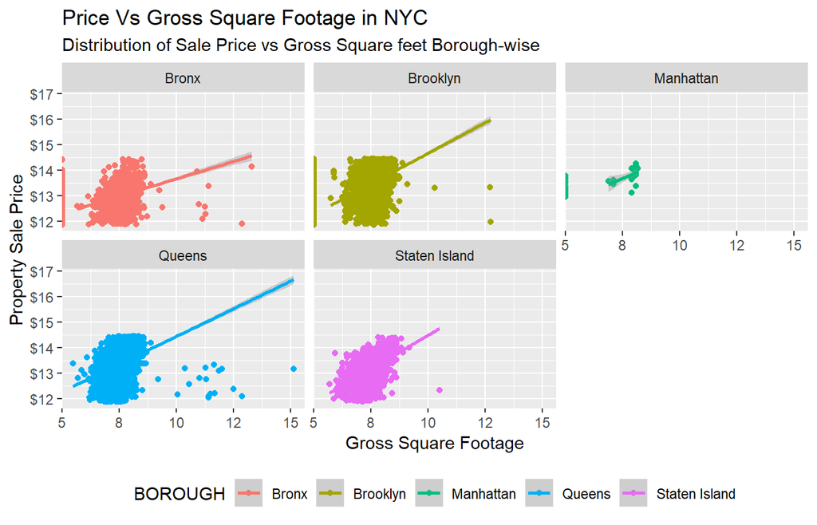

```r
ggplot(data = nyc_data_grosssqfeet, aes(x = log(nyc_data_grosssqfeet$GROSS.SQUARE.FEET), y = log(nyc_data_grosssqfeet$SALE.PRICE), color = `BOROUGH`)) +
  geom_jitter() +
  geom_smooth(method = "lm") +
  facet_wrap(~ BOROUGH) +
  ggtitle("Price Vs Gross Square Footage in NYC",
          subtitle = "Distribution of Sale Price vs Gross Square feet Borough-wise") +
  scale_y_continuous("Property Sale Price", labels = scales::dollar) +
  scale_x_continuous("Gross Square Footage", labels = scales::comma) +
  theme(legend.position = "bottom")
```

We can see a similar trend as we saw with the land square footage. The sale price increases with the gross square footage. The ones for Mahattan is interesting. This seems to suggest that the square footage has a weak relationship with the sale price. This could be because Manhattan has a significant location premium being factored into the price, even more so than the square footage.

For the sold properties with gross square feet of zero, we will replace them with NAs as we will impute the data later on.

```r
data$GROSS.SQUARE.FEET[data$GROSS.SQUARE.FEET == 0] <- NA
```

#### 2.4.2.3 YEAR.BUILT

For YEAR.BUILT, we replace any house with the year built before 1776 to NA’s.

```r
data$YEAR.BUILT[data$YEAR.BUILT <= 1776] <- NA
```

### 2.4.3 Boroughs

Let us see which borough recorded the the most property sales and which borough is the most expensive by avg. sale price.

[figure not shown]

```r
p1 <- ggplot(data = data, aes(x = `BOROUGH`)) +
  geom_bar() +
  ggtitle("In-Demand Borough in NYC") +
  scale_y_continuous("# of Property Sales", labels = scales::comma) +
  scale_x_discrete("Borough")

p2 <- ggplot(data = data, aes(x = `BOROUGH`, y = mean(`SALE.PRICE`))) +
  geom_bar(stat = "identity") +
  ggtitle("Most Expensive Borough in NYC", subtitle = "Avg. Property Sale Price in NYC") +
  scale_y_continuous("Avg Sale Price", labels = scales::dollar) +
  scale_x_discrete("Borough")

grid.arrange(p1, p2, ncol = 1)
```

### 2.4.4 Neigborhoods

Now that we have explored the sale price according to the boroughs, let us check for the most expensive neighborhoods.

We will only take the top ten neigborhoods as it will be difficult to plot all the neighborhoods.

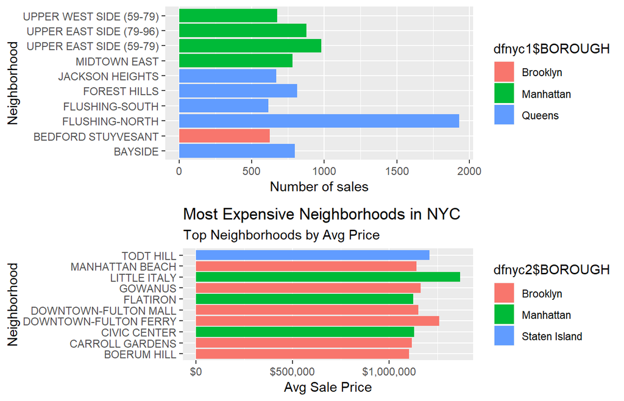

```r
dfnyc1<-as.data.frame(table(data$BOROUGH, data$NEIGHBORHOOD))
names(dfnyc1) <- c('BOROUGH','NEIGHBORHOOD', 'Freq')
dfnyc1 <- dfnyc1 %>% arrange(desc(Freq)) %>% head(10)
p3<-ggplot(data = dfnyc1,aes(x=dfnyc1$NEIGHBORHOOD,y=dfnyc1$Freq,fill=dfnyc1$BOROUGH))+geom_bar(stat = "identity")+scale_y_continuous("Number of sales")+scale_x_discrete("Neighborhood")+coord_flip()

dfnyc2<-
  data %>% group_by(BOROUGH, NEIGHBORHOOD) %>%
  summarise(MeanSP = mean(`SALE.PRICE`)) %>%
  arrange(desc(MeanSP)) %>% head(10)

p4 <- ggplot(data = dfnyc2, aes(x = dfnyc2$NEIGHBORHOOD, y = dfnyc2$MeanSP, fill = dfnyc2$BOROUGH)) +
  geom_bar(stat = "identity") +
  coord_flip() +
  ggtitle("Most Expensive Neighborhoods in NYC",
          subtitle = "Top Neighborhoods by Avg Price") +
  scale_y_continuous("Avg Sale Price", labels = scales::dollar) +
  scale_x_discrete("Neighborhood")

grid.arrange(p3,p4,ncol=1)
```

From the above graphs we can see that the most in-demand neighborhood is in Queens and the most expensive neighborhood by average price is in Little Italy in Manhattan.

### 2.4.5 Buildings

Let us explore the top ten most in-demand building class and the most expensive building class and to what borough they belong to.

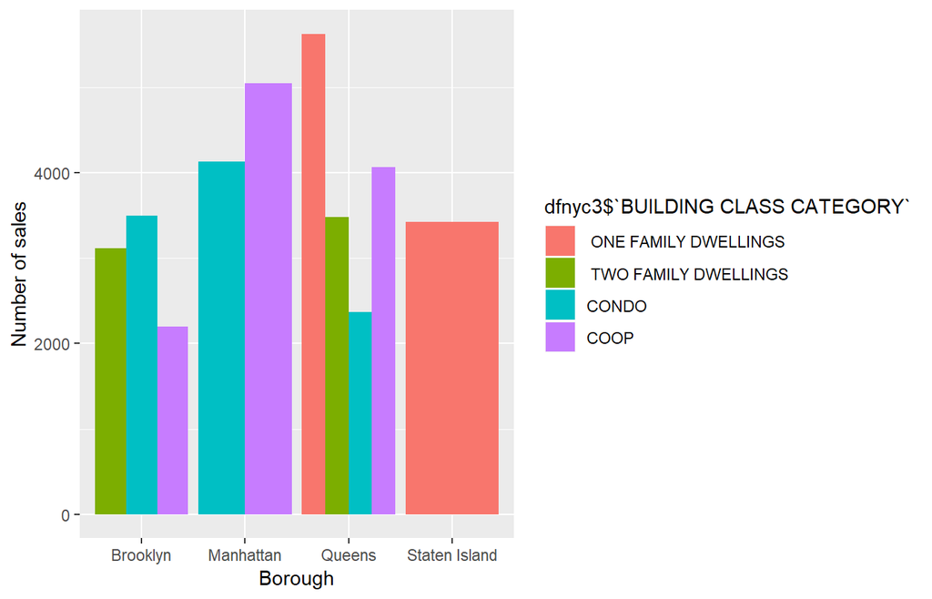

```r
dfnyc3<-as.data.frame(table(data$BOROUGH, data$BUILDING.CLASS.CATEGORY))
names(dfnyc3) <- c('BOROUGH','BUILDING CLASS CATEGORY', 'Freq')
dfnyc3 <- dfnyc3 %>% arrange(desc(Freq)) %>% head(10)
ggplot(data = dfnyc3,aes(x=dfnyc3$BOROUGH,y=dfnyc3$Freq,fill=dfnyc3$`BUILDING CLASS CATEGORY`))+geom_bar(stat = "identity",position = "dodge")+scale_y_continuous("Number of sales")+scale_x_discrete("Borough")
```

From the above diagram, it is clear that the one family dwellings are very popular in Queens and Staten Island. Condos are particularly in demand in Manhattan and in Brooklyn.

Now lets take a look at the most expensive building class.

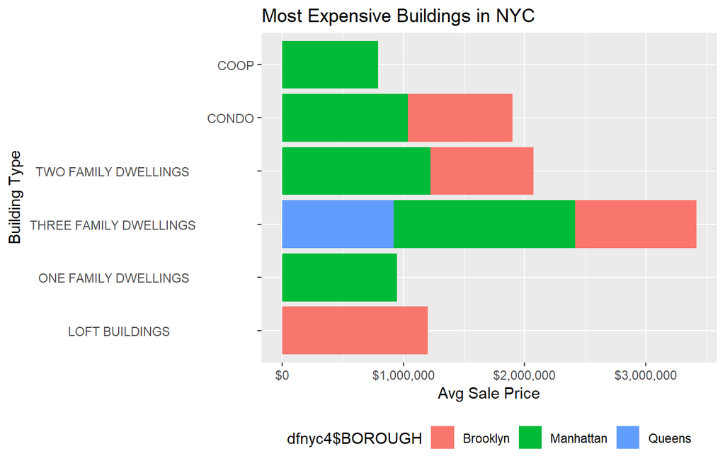

```r
dfnyc4<-
  data %>% group_by(BOROUGH,BUILDING.CLASS.CATEGORY ) %>%
  summarise(MeanSP = mean(`SALE.PRICE`)) %>%
  arrange(desc(MeanSP)) %>% head(10)

ggplot(data = dfnyc4, aes(x = dfnyc4$BUILDING.CLASS.CATEGORY, y = dfnyc4$MeanSP, fill = dfnyc4$BOROUGH)) +
  geom_bar(stat = "identity") +
  coord_flip() +
  ggtitle("Most Expensive Buildings in NYC") +
  scale_y_continuous("Avg Sale Price", labels = scales::dollar) +
  scale_x_discrete("Building Type") + theme(legend.position = "bottom")
```

From the above graph we can see that the most expensive buildings are the three-family-dwellings in Manhattan and Brooklyn.

## 2.5 Data Imputation

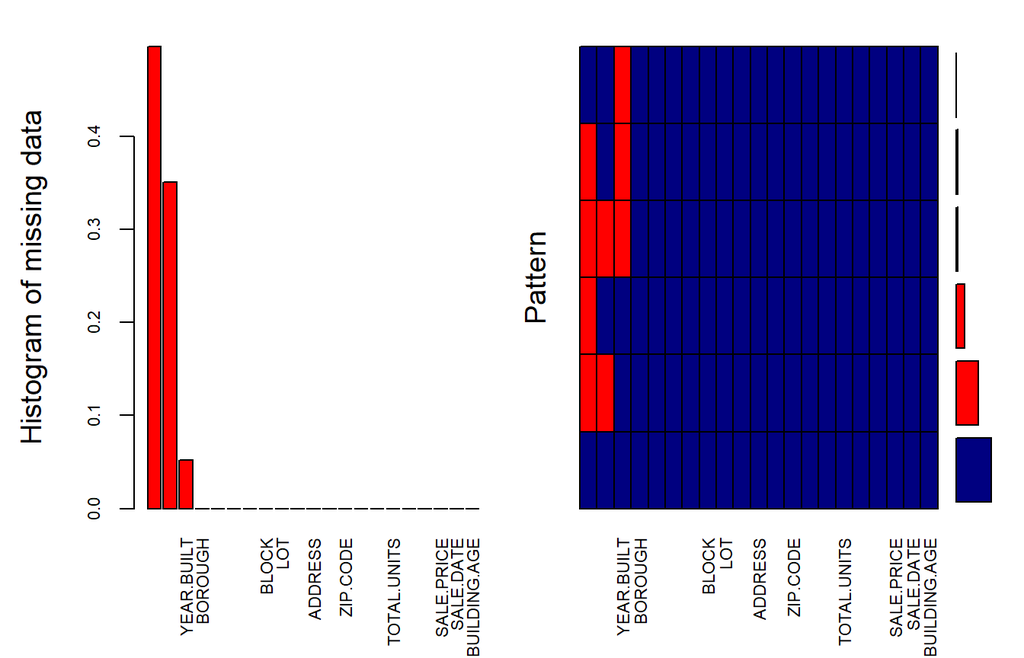

```
##
##  Variables sorted by number of missings:
##                        Variable      Count
##               GROSS.SQUARE.FEET 0.49656577
##                LAND.SQUARE.FEET 0.35059476
##                      YEAR.BUILT 0.05197929
##                         BOROUGH 0.00000000
##                    NEIGHBORHOOD 0.00000000
##         BUILDING.CLASS.CATEGORY 0.00000000
##            TAX.CLASS.AT.PRESENT 0.00000000
##                           BLOCK 0.00000000
##                             LOT 0.00000000
##       BUILDING.CLASS.AT.PRESENT 0.00000000
##                         ADDRESS 0.00000000
##                APARTMENT.NUMBER 0.00000000
##                        ZIP.CODE 0.00000000
##               RESIDENTIAL.UNITS 0.00000000
##                COMMERCIAL.UNITS 0.00000000
##                     TOTAL.UNITS 0.00000000
##       TAX.CLASS.AT.TIME.OF.SALE 0.00000000
##  BUILDING.CLASS.AT.TIME.OF.SALE 0.00000000
##                      SALE.PRICE 0.00000000
##                       SALE.DATE 0.00000000
##                    BUILDING.AGE 0.00000000
```

```r
#Analyzed Missing values

aggr_plot = aggr(data, col=c('navyblue','red'), numbers=TRUE, sortVars=TRUE, labels=names(data), cex.axis=.7, gap=3, ylab=c("Histogram of missing data","Pattern"))
```

```r
#remove easement columns all NA's and TOTAL.UNITS
data <- data[,!colnames(data) %in% c('EASE.MENT','X','TOTAL.UNITS')]

summary(data)
```

```
##           BOROUGH                       NEIGHBORHOOD
##  Bronx        : 3692   FLUSHING-NORTH         : 1931
##  Brooklyn     :11769   UPPER EAST SIDE (59-79):  979
##  Manhattan    : 9205   UPPER EAST SIDE (79-96):  878
##  Queens       :16151   FOREST HILLS           :  813
##  Staten Island: 5336   BAYSIDE                :  798
##                        MIDTOWN EAST           :  782
##                        (Other)                :39972
##                               BUILDING.CLASS.CATEGORY TAX.CLASS.AT.PRESENT
##   ONE FAMILY DWELLINGS                    :12065      1      :23327
##  COOP                                     :12038      2      :19991
##  CONDO                                    :10773      2C     : 1256
##   TWO FAMILY DWELLINGS                    : 9194      1A     : 1057
##   THREE FAMILY DWELLINGS                  : 2080             :  397
##   LOFT BUILDINGS                          :    3      1C     :  105
##  (Other)                                  :    0      (Other):   20
##      BLOCK            LOT         BUILDING.CLASS.AT.PRESENT
##  Min.   :    1   Min.   :   1.0   D4     : 9684
##  1st Qu.: 1430   1st Qu.:  21.0   R4     : 6784
##  Median : 3755   Median :  49.0   A1     : 4536
##  Mean   : 4500   Mean   : 356.5   A5     : 3930
##  3rd Qu.: 6670   3rd Qu.: 383.0   B2     : 3054
##  Max.   :16319   Max.   :9024.0   B1     : 2611
##                                   (Other):15554
##    ADDRESS          APARTMENT.NUMBER      ZIP.CODE     RESIDENTIAL.UNITS
##  Length:46153       Length:46153       10314  : 1063   Min.   :   0.000
##  Class :character   Class :character   11354  :  951   1st Qu.:   0.000
##  Mode  :character   Mode  :character   11375  :  863   Median :   1.000
##                                        10312  :  774   Mean   :   1.118
##                                        10306  :  690   3rd Qu.:   1.000
##                                        11235  :  689   Max.   :1844.000
##                                        (Other):41123
##  COMMERCIAL.UNITS   LAND.SQUARE.FEET  GROSS.SQUARE.FEET   YEAR.BUILT
##  Min.   : 0.00000   Min.   :      0   Min.   :    240   Min.   :1800
##  1st Qu.: 0.00000   1st Qu.:   1360   1st Qu.:   1304   1st Qu.:1925
##  Median : 0.00000   Median :   2187   Median :   1700   Median :1950
##  Mean   : 0.01361   Mean   :   2556   Mean   :   2194   Mean   :1951
##  3rd Qu.: 0.00000   3rd Qu.:   3142   3rd Qu.:   2250   3rd Qu.:1970
##  Max.   :22.00000   Max.   :4228300   Max.   :3750565   Max.   :2017
##                     NA's   :16181     NA's   :22918     NA's   :2399
##  TAX.CLASS.AT.TIME.OF.SALE BUILDING.CLASS.AT.TIME.OF.SALE
##  1:24524                   D4     : 9684
##  2:21619                   R4     : 7124
##  3:    0                   A1     : 4539
##  4:   10                   A5     : 3920
##                            B2     : 3051
##                            B1     : 2613
##                            (Other):15222
##    SALE.PRICE        SALE.DATE           BUILDING.AGE
##  Min.   : 142000   Min.   :2016-09-01   Min.   :   1
##  1st Qu.: 385000   1st Qu.:2016-11-30   1st Qu.:  52
##  Median : 585000   Median :2017-03-02   Median :  71
##  Mean   : 668498   Mean   :2017-03-01   Mean   : 168
##  3rd Qu.: 865000   3rd Qu.:2017-06-02   3rd Qu.:  94
##  Max.   :1890000   Max.   :2017-08-31   Max.   :2018
##
```

```r
borough_list <- c('Manhattan','Queens','Bronx','Brooklyn','Staten Island')

for (i in borough_list) {
Gross <- median(data$GROSS.SQUARE.FEET[data$BOROUGH==i & !is.na(data$GROSS.SQUARE.FEET)])
data$GROSS.SQUARE.FEET[data$BOROUGH==i & is.na(data$GROSS.SQUARE.FEET)] <- Gross

Land <- median(data$LAND.SQUARE.FEET[data$BOROUGH==i & !is.na(data$LAND.SQUARE.FEET)])
data$LAND.SQUARE.FEET[data$BOROUGH==i & is.na(data$LAND.SQUARE.FEET)] <- Land

Year_Built <- median(data$YEAR.BUILT[data$BOROUGH==i & !is.na(data$YEAR.BUILT)])
data$YEAR.BUILT[data$BOROUGH==i & is.na(data$YEAR.BUILT)] <- Year_Built
}
summary(data$GROSS.SQUARE.FEET)
```

```
##    Min. 1st Qu.  Median    Mean 3rd Qu.    Max.
##     240    1568    1988    2293    2904 3750565
```

```r
summary(data$LAND.SQUARE.FEET)
```

```
##    Min. 1st Qu.  Median    Mean 3rd Qu.    Max.
##       0    1682    2017    2420    2750 4228300
```

```r
summary(data$YEAR.BUILT)
```

```
##    Min. 1st Qu.  Median    Mean 3rd Qu.    Max.
##    1800    1925    1950    1951    1966    2017
```

We imputed the 3 columns that had some missing values: GROSS.SQUARE.FEET, LAND.SQUARE.FEET and YEAR.BUILT. We imputed the values by taking the median value for the variable for the borough it is in.

#### 2.5.0.1 Remove Outliers for LAND.SQUARE.FEET and GROSS.SQUARE.FEET –>

Now that we have inputed the NA’s value in LAND.SQUARE.FEET and GROSS.SQUARE.FEET we can remove the outliers for these variables.

```r
data_rm_outliers_gsq_feet <- data

summary(data$GROSS.SQUARE.FEET)
```

```
##    Min. 1st Qu.  Median    Mean 3rd Qu.    Max.
##     240    1568    1988    2293    2904 3750565
```

```r
data$GROSS.SQUARE.FEET <- remove_outliers(data_rm_outliers_gsq_feet$GROSS.SQUARE.FEET,4)


data <- data[data$GROSS.SQUARE.FEET!=-999999,]

summary(data$GROSS.SQUARE.FEET)
```

```
##    Min. 1st Qu.  Median    Mean 3rd Qu.    Max.
##    1068    1568    1988    2177    3024    4900
```

```r
data_rm_outliers_lsq_feet <- data

summary(data$LAND.SQUARE.FEET)
```

```
##    Min. 1st Qu.  Median    Mean 3rd Qu.    Max.
##       0    1682    2000    2254    2750   38862
```

```r
data$LAND.SQUARE.FEET[data$LAND.SQUARE.FEET!=0] <-remove_outliers(data_rm_outliers_lsq_feet$LAND.SQUARE.FEET[data_rm_outliers_lsq_feet$LAND.SQUARE.FEET!=0],1)


data <- data[data$LAND.SQUARE.FEET!=-999999,]

summary(data$LAND.SQUARE.FEET)
```

```
##    Min. 1st Qu.  Median    Mean 3rd Qu.    Max.
##       0    1682    2000    1981    2750    4352
```

We implemented the same outlier detection (BOX Plot method) we used for SALE.PRICE. When we were removing outliers for LAND.SQUARE.FEET we ignored 0 values as 0 is for condo building and we dont want to remove these.

After removing all outliers dataset now has 41186 elements. –>

### 2.5.1 Check Variable Distribution

#### 2.5.1.1 SALE.PRCIE

Want to Check if the distrbution of SALE.PRICE is normal, if not covert to normal through transformation

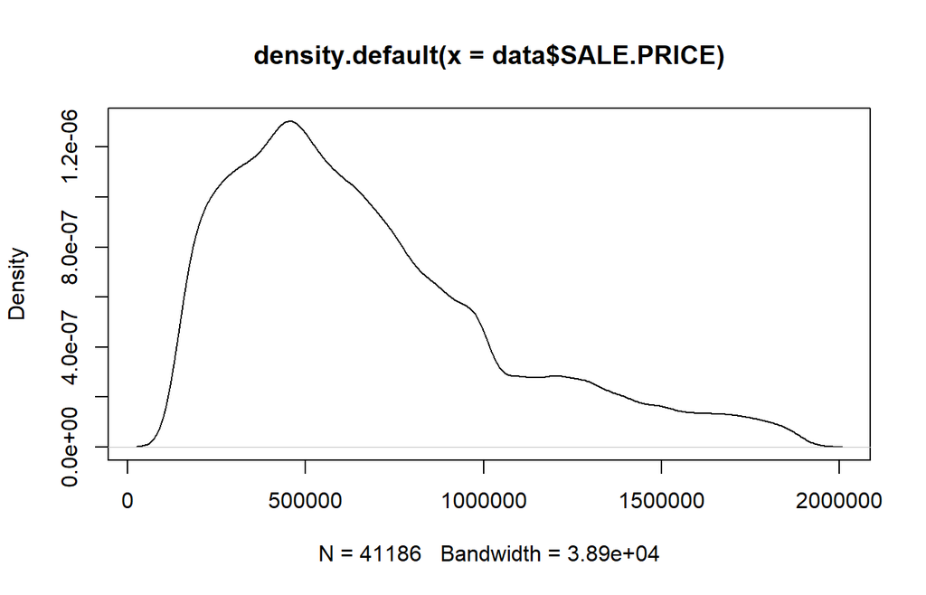

```r
plot(density(data$SALE.PRICE))
```

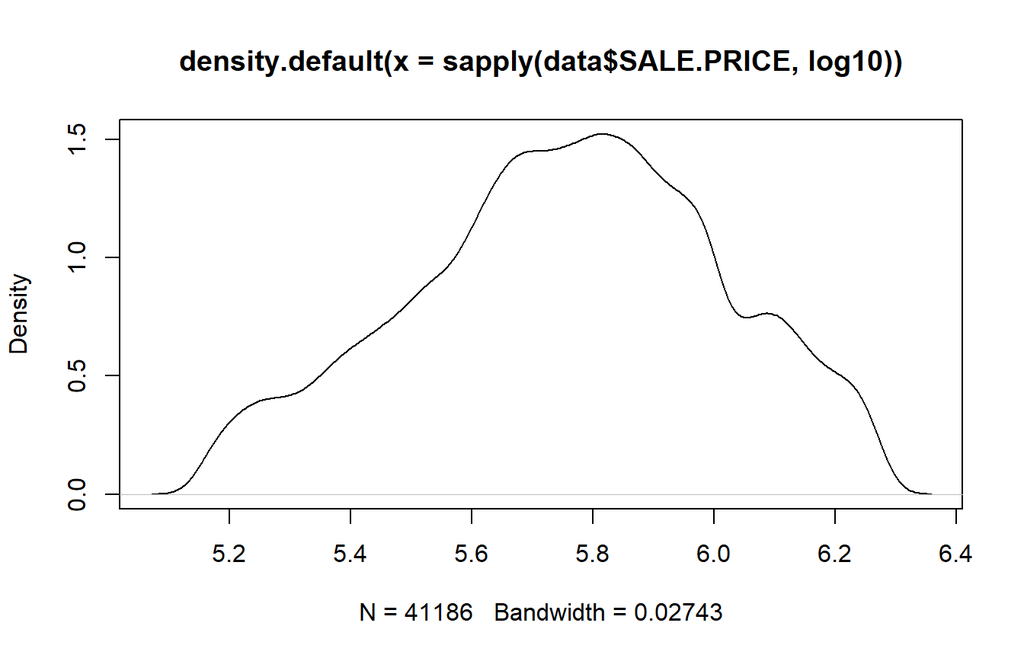

```r
#Use log transformation to change to normal distrubution

plot(density(sapply(data$SALE.PRICE, log10)))
```

```r
#Update SALE.PRICE

data$SALE.PRICE <- sapply(data$SALE.PRICE, log10)
```

We can see intially the SALE.PRICE was skewed towards the lower values, we used a log transformation to create a more normal distribution.

# 3 Modelling

Before we can run the model we need to ensure all our variables are numeric. For any categorical variables we need to choose a way to encode it.

## 3.1 Encoding Categorical Variables

```r
encod_Categories <- function (x,y) {
  z = y
  for (i in levels(x)) {
    encod_value <- median(y[x==i])

    z[x==i] <-  encod_value
    }
  z

}

#Find all factor variables to encod

is.fact <- cbind('BOROUGH','NEIGHBORHOOD','BUILDING.CLASS.CATEGORY','TAX.CLASS.AT.PRESENT','ZIP.CODE','BUILDING.CLASS.AT.TIME.OF.SALE')

encod_data <- as.data.frame(data[,colnames(data)%in%is.fact])



for (i in 1:NCOL(encod_data)){

  encod_data[,i] <- encod_Categories(encod_data[,i],data$SALE.PRICE)

}

#Confirm all variables are numeric
str(encod_data)
```

```
## 'data.frame':    41186 obs. of  6 variables:
##  $ BOROUGH                       : num  5.91 5.91 5.91 5.91 5.91 ...
##  $ NEIGHBORHOOD                  : num  5.89 5.89 5.89 5.89 5.89 ...
##  $ BUILDING.CLASS.CATEGORY       : num  5.61 5.61 5.61 5.61 5.61 ...
##  $ TAX.CLASS.AT.PRESENT          : num  5.76 5.76 5.76 5.76 5.76 ...
##  $ ZIP.CODE                      : num  5.9 5.9 5.9 5.9 5.9 ...
##  $ BUILDING.CLASS.AT.TIME.OF.SALE: num  5.49 5.49 5.49 5.49 5.49 ...
```

```r
table(data$BUILDING.CLASS.CATEGORY,encod_data$BUILDING.CLASS.CATEGORY)
```

```
##
##                                             5.60745502321467
##    LOFT BUILDINGS                                          0
##    ONE FAMILY DWELLINGS                                    0
##    TAX CLASS 3 - UNTILITY PROPERTIES                       0
##    THEATRES                                                0
##    THREE FAMILY DWELLINGS                                  0
##    TWO FAMILY DWELLINGS                                    0
##   CONDO                                                    0
##   COOP                                                 12011
##
##                                             5.69897000433602
##    LOFT BUILDINGS                                          0
##    ONE FAMILY DWELLINGS                                 8377
##    TAX CLASS 3 - UNTILITY PROPERTIES                       0
##    THEATRES                                                0
##    THREE FAMILY DWELLINGS                                  0
##    TWO FAMILY DWELLINGS                                    0
##   CONDO                                                    0
##   COOP                                                     0
##
##                                             5.81291335664286
##    LOFT BUILDINGS                                          0
##    ONE FAMILY DWELLINGS                                    0
##    TAX CLASS 3 - UNTILITY PROPERTIES                       0
##    THEATRES                                                0
##    THREE FAMILY DWELLINGS                                  0
##    TWO FAMILY DWELLINGS                                 8066
##   CONDO                                                    0
##   COOP                                                     0
##
##                                             5.88366143515362
##    LOFT BUILDINGS                                          0
##    ONE FAMILY DWELLINGS                                    0
##    TAX CLASS 3 - UNTILITY PROPERTIES                       0
##    THEATRES                                                0
##    THREE FAMILY DWELLINGS                                  0
##    TWO FAMILY DWELLINGS                                    0
##   CONDO                                                10772
##   COOP                                                     0
##
##                                             5.88930170250631
##    LOFT BUILDINGS                                          0
##    ONE FAMILY DWELLINGS                                    0
##    TAX CLASS 3 - UNTILITY PROPERTIES                       0
##    THEATRES                                                0
##    THREE FAMILY DWELLINGS                               1960
##    TWO FAMILY DWELLINGS                                    0
##   CONDO                                                    0
##   COOP                                                     0
```

We can see that all the columns are now numeric. Each level has been replaced with the median sale price value for that variable.

## 3.2 Create dataset for modelling

Now that we have all the categorical variables converted to numeric,we can create a modelling dataset that includes the SALE.DATE field, inital numeric columns and encoded categorical columns.

```r
is.num <- sapply(data, is.numeric)


data_model <- (data.frame((data[,is.num]),encod_data,data$SALE.DATE))

#Remove columns

data_model <- data_model[,!colnames(data_model)%in%c('YEAR.BUILT','TAX.CLASS.AT.PRESENT','RESIDENTIAL.UNITS','COMMERCIAL.UNITS','TAX.CLASS.AT.TIME.OF.SALE','BUILDING.CLASS.AT.TIME.OF.SALE')]
```

We also remove all columns that a typically homeowner would not know about there house, we need to do this as our business model requires the user to enter information about the house.

## 3.3 Look at Correalation

```r
cor_result=rcorr(as.matrix(data_model[,1:10]))


# ++++++++++++++++++++++++++++
# flattenCorrMatrix - makes it easier to read (in my opinion)
# ++++++++++++++++++++++++++++
flattenCorrMatrix <- function(cormat, pmat) {
  ut <- upper.tri(cormat)
  data.frame(
    row = rownames(cormat)[row(cormat)[ut]],
    column = rownames(cormat)[col(cormat)[ut]],
    cor  =(cormat)[ut],
    p = pmat[ut]
  )
}

#Simple method to flatten (if that how you want to look at it)
cor_result_flat = flattenCorrMatrix(cor_result$r, cor_result$P)
cor_result_flat[cor_result_flat$cor >0.9,]
```

```
## [1] row    column cor    p
## <0 rows> (or 0-length row.names)
```

```r
cor_result_flat[abs(cor_result_flat$cor) <0.1&cor_result_flat$column=='SALE.PRICE',]
```

```
##                row     column        cor p
## 9 LAND.SQUARE.FEET SALE.PRICE -0.0879217 0
```

## 3.4 Split into Training & Test Sets

We split the data into 80% training data and 20% testing data, the data is balanced on the Borough variable to ensure each data is representative of the initial data set.

```r
#set.seed(456292)

#Create index to split data
train_set <- createDataPartition(data_model$BOROUGH, p = 0.8, list = FALSE)



#Create train and test data
train_data <- data_model[train_set,]
test_data <- data_model[-train_set,]
```

## 3.5 Build Model

We decided to implement a linear regresion model. With linear regression the goal is to identify a line that best first the data. The line of best fit is the one where the prediction error is the least. Since the linear regression tries to reduce the prediction error between actual and predicted ,linear regression can become skewed by outliers in the data. We tried to reduce this by pre processing the data and removing the outliers.

We will create a basic linear regression on our train_data set using a 10 fold cross validation to help reduce over fitting.

```r
#reduce bias using cross validation
folds=10

fitControl <- trainControl(method="cv",number=folds)

#Implement Linear Regresion Model (lm)
LM_model <- train(SALE.PRICE~., data=train_data, method="lm",
metric = "MAE",
trControl = fitControl)
```

We chose to run the linear regression intially on all of our variables. We will now investigate if there is some variables we can remove that are of low signifiance.

## 3.6 Model Assessment

### 3.6.1 Variable Significance

```r
summary(LM_model)
```

```
##
## Call:
## lm(formula = .outcome ~ ., data = dat)
##
## Residuals:
##      Min       1Q   Median       3Q      Max
## -0.88551 -0.11546  0.01649  0.11642  0.87378
##
## Coefficients:
##                           Estimate Std. Error t value Pr(>|t|)
## (Intercept)             -6.245e+00  2.031e-01 -30.750  < 2e-16 ***
## BLOCK                   -3.623e-06  3.621e-07 -10.004  < 2e-16 ***
## LOT                     -4.542e-05  2.094e-06 -21.689  < 2e-16 ***
## LAND.SQUARE.FEET         3.515e-05  1.131e-06  31.082  < 2e-16 ***
## GROSS.SQUARE.FEET        4.262e-05  1.884e-06  22.623  < 2e-16 ***
## BUILDING.AGE            -1.259e-05  2.422e-06  -5.197 2.04e-07 ***
## BOROUGH                  2.355e-01  1.756e-02  13.414  < 2e-16 ***
## NEIGHBORHOOD             4.170e-01  1.397e-02  29.839  < 2e-16 ***
## BUILDING.CLASS.CATEGORY  7.405e-01  1.192e-02  62.113  < 2e-16 ***
## ZIP.CODE                 3.137e-01  1.450e-02  21.640  < 2e-16 ***
## data.SALE.DATE           1.184e-04  9.837e-06  12.036  < 2e-16 ***
## ---
## Signif. codes:  0 '***' 0.001 '**' 0.01 '*' 0.05 '.' 0.1 ' ' 1
##
## Residual standard error: 0.1875 on 32939 degrees of freedom
## Multiple R-squared:  0.4581, Adjusted R-squared:  0.4579
## F-statistic:  2784 on 10 and 32939 DF,  p-value: < 2.2e-16
```

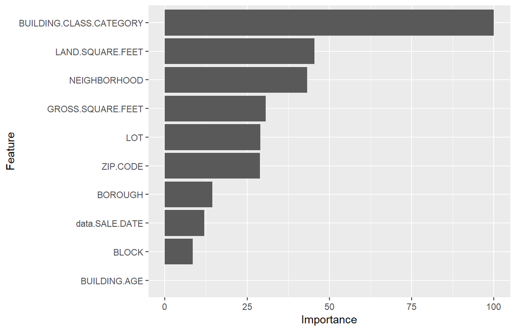

```r
importance    <- varImp(LM_model)

ggplot(importance)
```

```r
print(LM_model)
```

```
## Linear Regression
##
## 32950 samples
##    10 predictor
##
## No pre-processing
## Resampling: Cross-Validated (10 fold)
## Summary of sample sizes: 29655, 29654, 29656, 29654, 29654, 29654, ...
## Resampling results:
##
##   RMSE       Rsquared   MAE
##   0.1875201  0.4580669  0.1460992
##
## Tuning parameter 'intercept' was held constant at a value of TRUE
```

The most important variables are BUILDING.CLASS.CATEGORY, NEIGHBOURHOOD, LAND.SQUARE.FEET and GROSS.SQUARE.FEET. This was generally in line with what are assumptions were and what you hear about the housing market. It is more about the house and location then the size and age of the house. We were a little surprised that age had little to no effect but this could be because age is sometimes hard to judge with a house that has gone through extensive renovations.

All of the variables have low p-values, we can conclude our model is statistically significant.

The model has a Rsquared of 0.46, this means that the only 46% of the SALE.PRICE variable variation is explained by our linear model. This was a lower Rquared then we expected since all of our variables are shown to be significant. We will now look at the residuals plot to help determine if the linear model is good or not.

### 3.6.2 Check Residual of Linear Model

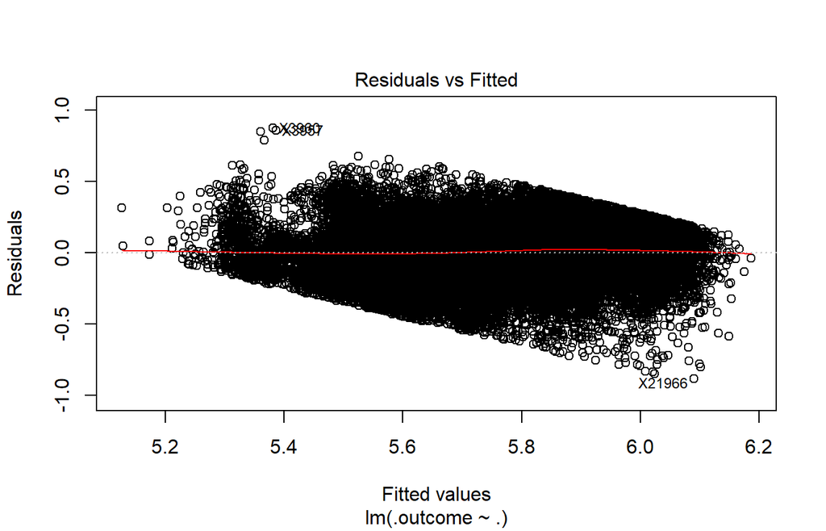

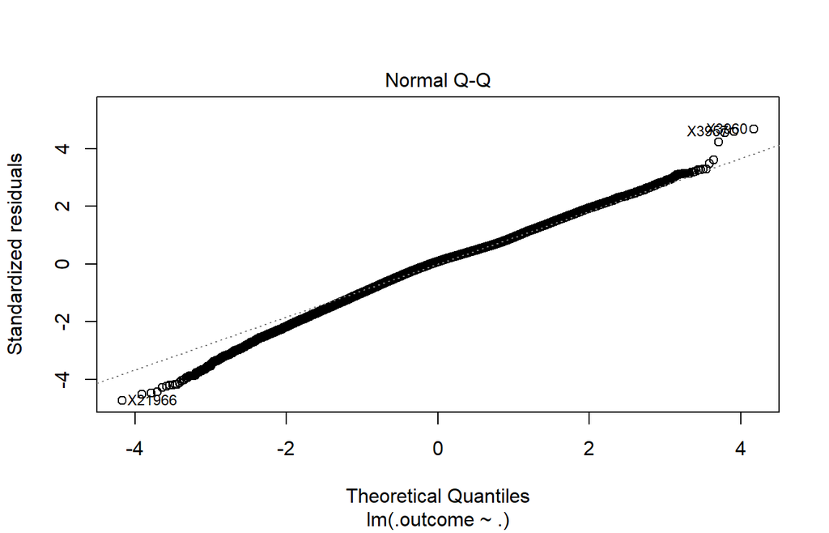

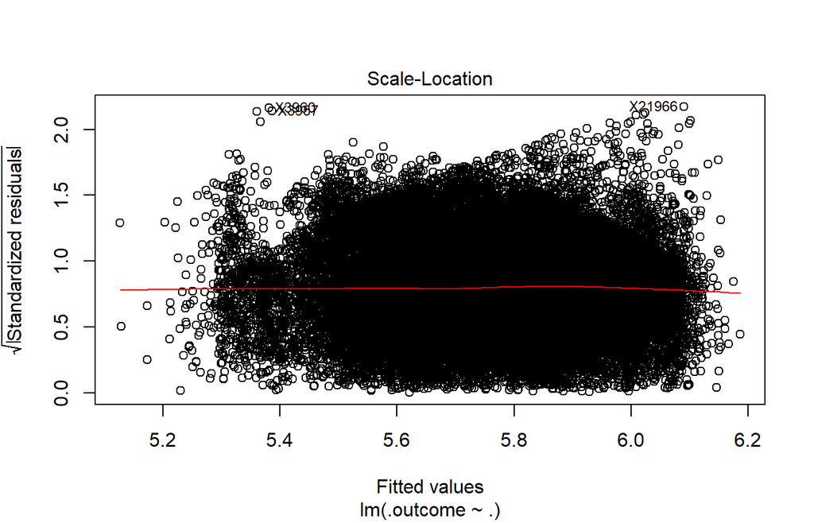

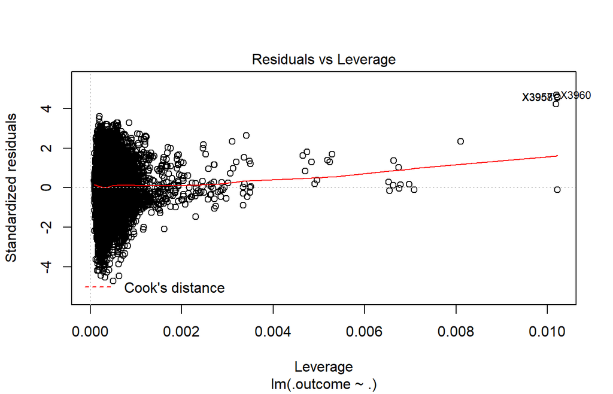

```r
plot(LM_model$finalModel)
```

With linear regression we make the assumption that the errors will be normal distributed, to test that we will look at the Normal Q-Q plot. This plot compares the quantiles of our errors to the quantiles of the normal distribution. If the errors of our model was exactly normal we would expect to see a straight line. We can see from the graph the line is fairly straight but curves off near the bottom quantiles.

Next we want to look at the Standardize residuals charted against the predicted value. We expect the residuals to be random and there should be no observed pattern. From the 3rd Chart we can the residuals look pretty random and there does not appear to be any pattern.

### 3.6.3 Accuracy of Linear regression model

Now that we confirmed that we are using signicant variables and residuals are random. We can look into the accuracy of the model on the test data.

```r
# Predict Test results
LM_model.pred <- predict(LM_model, test_data)


actuals_preds <- data.frame(cbind(actuals=test_data$SALE.PRICE, predicteds=LM_model.pred ))

actuals_preds <- sapply(actuals_preds, function(x) 10^x)
# Check Accuracy of Model
min_max_accuracy <- mean (apply(actuals_preds, 1, min) / apply(actuals_preds, 1, max))
min_max_accuracy
```

```
## [1] 0.737281
```

```r
mape <- mean(abs((actuals_preds[,"predicteds"]  - actuals_preds[,"actuals"]))/actuals_preds[,"actuals"])

mape
```

```
## [1] 0.3732223
```

```r
#Within 10%


Within10 <- ifelse(abs((actuals_preds[,"predicteds"] - actuals_preds[,"actuals"]))/actuals_preds[,"actuals"]>0.1,0,1)

basic_LM_Accuracy <- mean(Within10)

basic_LM_Accuracy
```

```
## [1] 0.2058038
```

### 3.6.4 Linear Regression After Clustering

We wanted to test if we could improve the accuracy of the linear regression by first clustering the data using K means and then create a linear regression model for each cluster. Our assumption is that there is different subsets of the housing market and by clustering we will identify them and create specfic models for them.

#### 3.6.4.1 Data Normalization

Since the K-means algorithm using distance to find the nearest point we need to ensure all the variables are on the same range. We do this by normalizing the data. We also need to remove our Target variable SALE.PRICE from the cluster data.

```r
#exclude Date column for clustering

is.num <- sapply(data_model, is.numeric)


df <- data.frame((data_model[,is.num]),encod_data)


#remove Sale.Price

df<- df[,!colnames(df)%in%c('SALE.PRICE')]

normalize = function(x) {
  return ((x - min(x)) / (max(x) - min(x)))
}

df = as.data.frame(lapply(df, normalize))
```

#### 3.6.4.2 Finding Optimal Number of Clusters (K)

Before we run the K Mean algorithm we need to find the optimal K clusters. To find the optimal number of clusters we used the Elbow method. The elbow method finds the optimal K value by running mulptiple K-Means for K from 1 to N and calculateing the Sum of Squared errors (SSE). We then plot each SSE for each K, we then chose an optimal value of K such that it has a low SSE but further increase of K would make little improvement to the SSE. That K value would be the elbow point of the plot.

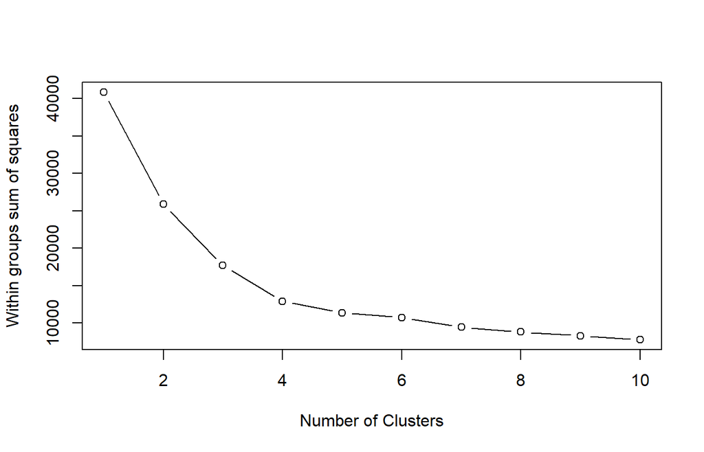

```r
#Find Optimal K using Elbow method

wssplot <- function(data, nc=15, seed=1234){
  wss <- (nrow(data)-1)*sum(apply(data,2,var))
  for (i in 2:nc){
    set.seed(seed)
    wss[i] <- sum(kmeans(data, centers=i, nstart=5)$withinss)}
  plot(1:nc, wss, type="b", xlab="Number of Clusters",
       ylab="Within groups sum of squares")
  }

wssplot(df, nc=10)
```

Based on the Elbow method, we found the optimal number to be 4. Beyond 4, we see gradually decreasing improvements on the SSE.

#### 3.6.4.3 Building K-Means Model

We are now able to create the K means model, we are creating 4 clusters with the 4 corresponding centroids being randomly chosen 15 times.

```r
set.seed(9897665)

kmeans.result <- kmeans(df, centers=4, nstart=15, iter.max = 100)
```

#### 3.6.4.4 Visualize Model with PCA

We will use Principle Componet Analysis (PCA) to help us Visualize our clusters. PCA works by reducing dimensoinality of the data. We want to reduce the dimensionality to 2d because it will allow us to graph the clusters. PCA creates new columns that are linearly uncorrelated variables, and sorts thems in descending where PC1 will account for the highest variability of the data, and PC2 will be seocnd most and so on.

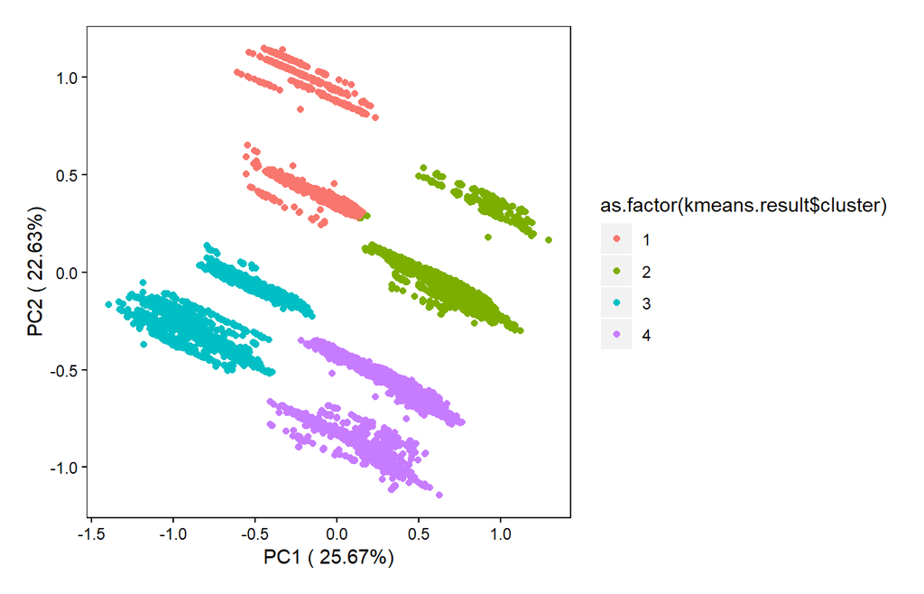

```r
df_pca <- prcomp(df)
df_out <- as.data.frame(df_pca$x)

p<-ggplot(df_out,aes(x=PC1,y=PC2,color = as.factor(kmeans.result$cluster ) ))
theme<-theme(panel.background = element_blank(),panel.border=element_rect(fill=NA),panel.grid.major = element_blank(),panel.grid.minor = element_blank(),strip.background=element_blank(),axis.text.x=element_text(colour="black"),axis.text.y=element_text(colour="black"),axis.ticks=element_line(colour="black"),plot.margin=unit(c(1,1,1,1),"line"))
percentage <- round(df_pca$sdev / sum(df_pca$sdev) * 100, 2)
percentage <- paste( colnames(df_out), "(", paste( as.character(percentage), "%", ")", sep="") )

p<-p+geom_point()+theme+xlab(percentage[1]) + ylab(percentage[2])

p
```

Looking at the visualized data we can see that the clusters are well generlized and there is almost no overlap. Cluster 3 and 4 are almost fully homogeneous from each other. Cluster 1 and 2 seems to be some small overlapping on the bottom right of cluster 1.

#### 3.6.4.5 Building LM model for each cluster

We now build a linear regression model for each Cluster.

```r
data_cluster <- data.frame(data_model,cluster=as.factor(kmeans.result$cluster))
#create blank dataframe to hold all clsuters
lmmodels_output <- data.frame(matrix(ncol = 5, nrow = 0))
x <- c("ClusterNumber", "MinMAxAccuracy", "MAPE","Within10","NumberofRecords")
colnames(lmmodels_output) <- x
for (i in levels(data_cluster$cluster)){
  train_set_c <- createDataPartition(data_cluster$BOROUGH[data_cluster$cluster==i], p = 0.8, list = FALSE)
  #Create train and test data
  train_data_c <- data_model[train_set_c,]
  test_data_C <- data_model[-train_set_c,]
  lmmodels <- train(SALE.PRICE~., data=train_data_c, method="lm",tuneLength = 50,
metric = "MAE",
trControl = fitControl)
  LM_model.pred <- predict(lmmodels, test_data_C)

  actuals_preds <- data.frame(cbind(actuals=test_data_C$SALE.PRICE, predicteds=LM_model.pred ))
  actuals_preds <- sapply(actuals_preds, function(x) 10^x)
  # Check Accuracy of Model
  min_max_accuracy <- mean (apply(actuals_preds, 1, min) / apply(actuals_preds, 1, max))
  mape <- mean(abs((actuals_preds[,"predicteds"]  - actuals_preds[,"actuals"]))/actuals_preds[,"actuals"])
  Within10 <- ifelse(abs((actuals_preds[,"predicteds"] - actuals_preds[,"actuals"]))/actuals_preds[,"actuals"]>0.1,0,1)

  current_output <- data.frame(ClusterNumber = i,MinMAxAccuracy = min_max_accuracy,MAPE = mape,Within10 = mean(Within10) ,NumberofRecords = NROW(train_data_c))

  lmmodels_output <- rbind(lmmodels_output,current_output)


}

#Find Weighting Scores


lmmodels_output$WeightedWithin10 <- lmmodels_output$Within10 * lmmodels_output$NumberofRecords

lmmodels_output$WeightedMAPE<- lmmodels_output$MAPE * lmmodels_output$NumberofRecords

lmmodels_output$weightedMinMAxAccuracy<- lmmodels_output$MinMAxAccuracy * lmmodels_output$NumberofRecords

lmmodels_output
```

```
##   ClusterNumber MinMAxAccuracy      MAPE  Within10 NumberofRecords
## 1             1      0.6244313 0.7613816 0.1322709            7112
## 2             2      0.7144953 0.4648488 0.1810792            9200
## 3             3      0.7149207 0.4650945 0.1816674            9232
## 4             4      0.7136743 0.4043730 0.1677374            7407
##   WeightedWithin10 WeightedMAPE weightedMinMAxAccuracy
## 1         940.7109     5414.946               4440.956
## 2        1665.9288     4276.609               6573.357
## 3        1677.1534     4293.753               6600.148
## 4        1242.4306     2995.191               5286.186
```

```r
#Weight Within10 Accuracy
Clustered_LM_Accuracy <- sum(lmmodels_output$WeightedWithin10) / sum(lmmodels_output$NumberofRecords)

Clustered_LM_MAPE <- sum(lmmodels_output$WeightedMAPE) / sum(lmmodels_output$NumberofRecords)

Clustered_LM_MinMax <- sum(lmmodels_output$weightedMinMAxAccuracy) / sum(lmmodels_output$NumberofRecords)



Final_Table <- data.frame(Model = "Basic_LM",MinMAxAccuracy = round(min_max_accuracy,4),MAPE = round(mape,4),Within10 = round(basic_LM_Accuracy,4))
Final_Table  <- rbind(Final_Table,data.frame(Model = "Cluster_LM",MinMAxAccuracy = round(Clustered_LM_MinMax,4),MAPE = round(Clustered_LM_MAPE,4),Within10 = round(Clustered_LM_Accuracy,4)))

Final_Table  <- rbind(Final_Table,data.frame(Model = "%Difference",MinMAxAccuracy = round((Clustered_LM_MinMax / min_max_accuracy)  - 1,4)*100,MAPE = round((Clustered_LM_MAPE / mape)  - 1,4)*100,Within10 = round((Clustered_LM_Accuracy / basic_LM_Accuracy)  - 1,4)*100))



kable(Final_Table,align = 'c',caption = "Model Accuracy")
```

Model Accuracy

[output not shown]

We have created a model for each cluster, for each model we create a train and test data set based on the cluster data and ratioed on the borough variable. For each model we calculated the same accuracy metrics. We then create a weighted score for each accuracy metric, we do this by using the size of the cluster as the weight and times it by the accuracy metric.

We compared each of the accuracy metric to the basic LM model.

We observed the Cluster model was far worse in every category. One reason could be the k means model clustered all the unique and very different properties and linear regression has a hard time predicting. We can see there was one set of clusters that was significantly worse then the other ones.

### 3.6.5 Other Models

Would using a more resource intensive model improve the results significantly?

#### 3.6.5.1 Gradient Boosted Model (GBM)

GBM stands for Gradient Boosted model orboosted tree regression model. GBM works by first creating a basic linear regression model, then it calculates what examples had the largest residuals. The boosting refers to using the records with largest residual (poor predicted values) and training a new model of those values, this process is repeated until a certain stopping creteria is met.

The Boosted tree regression model has 3 parameters: tree depth, number of trees and the learning rate.

We used cross validation to find the optimal parameters.

```r
gbm_fitControl <- trainControl(## 10-fold CV
                           method = "repeatedcv",
                           number = 5,
                           ## repeated ten times
                           repeats = 5)


gbmGrid <-  expand.grid(interaction.depth = c(5,9),
                        n.trees = (5:10)*200,
                        shrinkage = 0.1,
                        n.minobsinnode = 20)


set.seed(825)
gbmFit1 <- train(SALE.PRICE ~ ., data = train_data,
                 method = "gbm",
                 trControl = gbm_fitControl,
                 ## This last option is actually one
                 ## for gbm() that passes through
                 verbose = FALSE,
                 tuneGrid = gbmGrid
                 )

gbmFit1
```

```
## Stochastic Gradient Boosting
##
## 32950 samples
##    10 predictor
##
## No pre-processing
## Resampling: Cross-Validated (5 fold, repeated 5 times)
## Summary of sample sizes: 26359, 26359, 26362, 26360, 26360, 26360, ...
## Resampling results across tuning parameters:
##
##   interaction.depth  n.trees  RMSE       Rsquared   MAE
##   5                  1000     0.1493934  0.6559543  0.1123638
##   5                  1200     0.1490146  0.6576528  0.1119685
##   5                  1400     0.1487718  0.6587303  0.1117277
##   5                  1600     0.1486025  0.6595012  0.1115447
##   5                  1800     0.1484661  0.6601286  0.1113920
##   5                  2000     0.1483565  0.6606407  0.1112714
##   9                  1000     0.1482263  0.6612358  0.1110019
##   9                  1200     0.1481189  0.6617637  0.1108690
##   9                  1400     0.1481215  0.6618057  0.1108238
##   9                  1600     0.1482041  0.6615149  0.1108451
##   9                  1800     0.1483035  0.6611596  0.1109049
##   9                  2000     0.1484627  0.6605301  0.1109750
##
## Tuning parameter 'shrinkage' was held constant at a value of 0.1
##
## Tuning parameter 'n.minobsinnode' was held constant at a value of 20
## RMSE was used to select the optimal model using the smallest value.
## The final values used for the model were n.trees = 1200,
##  interaction.depth = 9, shrinkage = 0.1 and n.minobsinnode = 20.
```

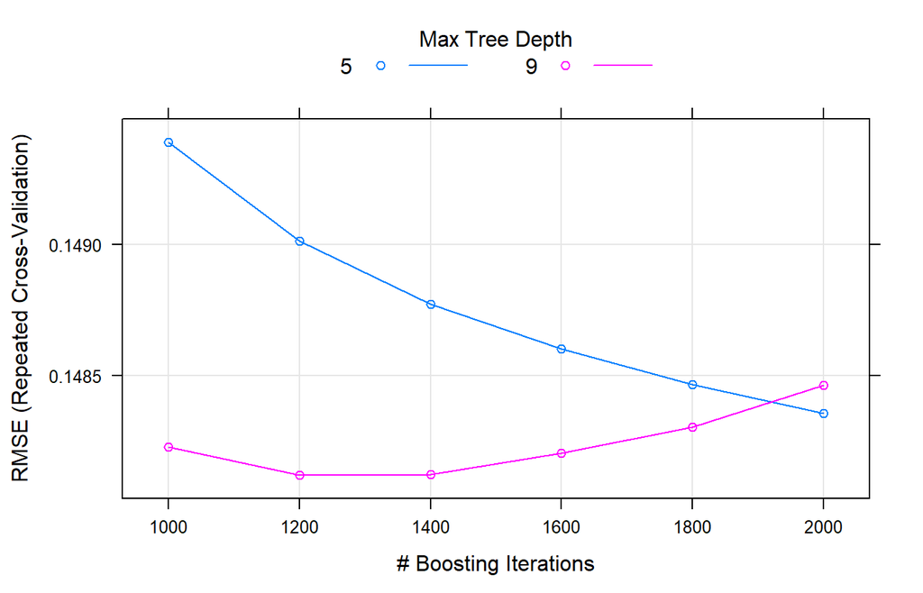

```r
plot(gbmFit1)
```

```r
XG_model.pred <- predict(gbmFit1, test_data)
#convert SALE.PRICE back to intial values


XG_actuals_preds <- data.frame(cbind(actuals=test_data$SALE.PRICE, predicteds=XG_model.pred ))
XG_actuals_preds <- sapply(XG_actuals_preds, function(x) 10^x)
# Check Accuracy of Model
XG_min_max_accuracy <- mean (apply(XG_actuals_preds, 1, min) / apply(XG_actuals_preds, 1, max))

XG_mape <- mean(abs((XG_actuals_preds[,"predicteds"]  - XG_actuals_preds[,"actuals"]))/XG_actuals_preds[,"actuals"])


XG_Within10 <- ifelse(abs((XG_actuals_preds[,"predicteds"] - XG_actuals_preds[,"actuals"]))/XG_actuals_preds[,"actuals"]>0.1,0,1)

XG_Within10_Accuracy <- mean(XG_Within10)


XG_Within10_Accuracy
```

```
## [1] 0.2810831
```

```r
Final_Table  <- rbind(Final_Table,data.frame(Model = "GBM",MinMAxAccuracy = round(XG_min_max_accuracy,4),MAPE = round(XG_mape,4),Within10 = round(XG_Within10_Accuracy,4)))

kable(Final_Table)
```

[output not shown]

We can see the GBM is much better among all 3 accuracy metrics.

# 4 Next Steps

The accuracy is still well below most commercial grade Housing Estimators. The largest one is the zestimate model created by zillow where the model achieved an accuracy of 71% of the properties within 10% of the actual sale prices. Next step would be to continue to refine the model and try to increase the accuracy by gathering more data and attributes on the properties. Some the of attributes we could look into collecting and spatial data on how close houses are amenties / highways / lakes / schools. We could also see if we could get data that reflects the property conditions.

https://www.zillow.com/zestimate/#acc

# 5 Deployment

With the current accuracy we would suggest not using this as the sole model to estimate / appraise properties. In the current configuration, we would deploy it as a secondary check to help provide confirmation of the property values. We could provide an estimated value on every property and in the case there is a dispute or a wide variance, we can use the estimate to help make our case how much the property is worth.

To help the clients better use the prediction model, we created a user interface where the user can input the zip code, neighborhood, property type, square footage and the property age and then the model will predict the estimated price. Note that the model used in the app is Gradient Boosted Model (GBM) which gives the best model accuracy among the three.